# Module 3: Excel & Data Analytics (7.5 Hours)

From Raw Data to Business Insights

Author

Dr Aniruddha Bonnerjee

Abstract

Session 1: Befriending the data and preparing for analytics

# Session 1: Befriending the Data + Cleaning Fundamentals

### Duration: 1.5 hours

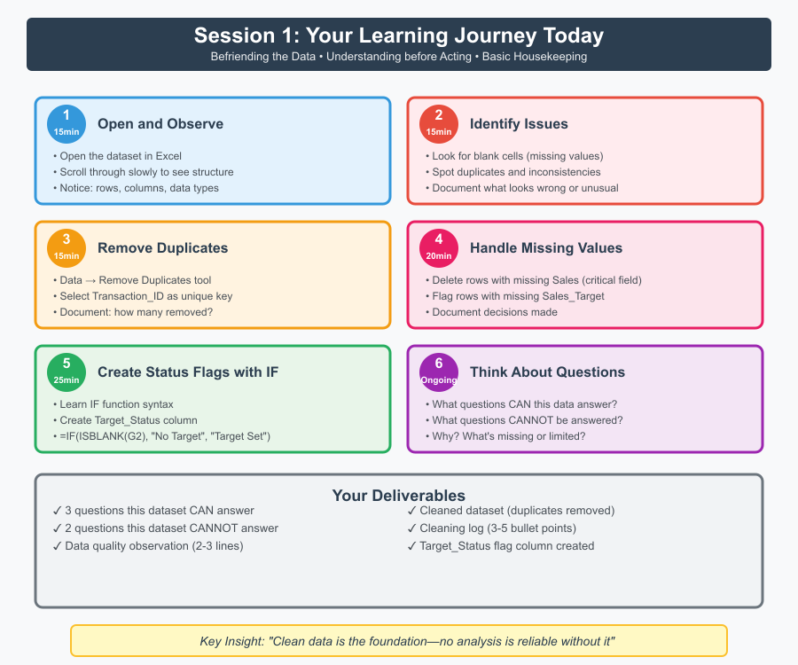

## Session Objective

By the end of this session, you will be able to: - Understand how real business datasets are structured - Identify what makes a dataset “clean” or “messy” - Remove duplicate records using Excel tools - Handle missing values with proper documentation - Use IF functions to create status flags - Translate business questions into data questions

## Key Concepts

### Data vs Information vs Insight

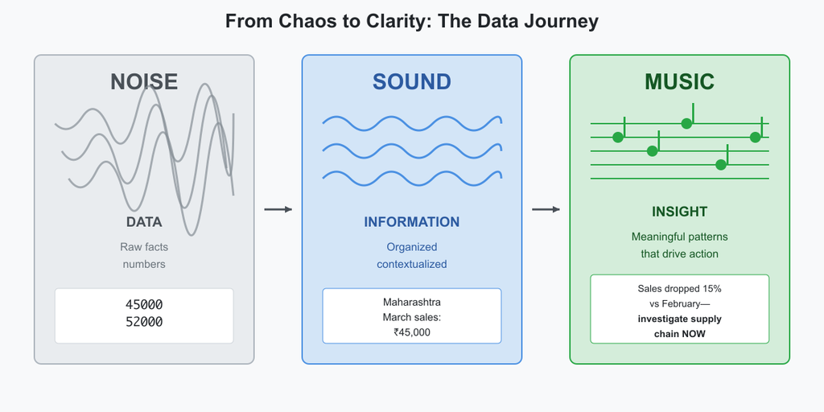

**Data** → Raw facts and numbers  
*Example: Sales = ₹45,000*

**Information** → Organized and contextualized data  
*Example: Maharashtra sales in March = ₹45,000*

**Insight** → Meaningful pattern or conclusion that drives decisions  
*Example: Maharashtra sales dropped 15% vs February, requiring immediate investigation*

### Understanding Dataset Structure

Every dataset has: - **Rows** = Individual records/transactions - **Columns** = Variables/attributes - **Headers** = Column names (should be clear and consistent) - **Data Types** = Numbers, text, dates, categories

**Ask yourself:** - What does each row represent? - What does each column measure? - What time period does this cover? - Are there any obvious patterns just from looking?

## Today’s Dataset

**Company Sales Performance Data**

This dataset contains sales transactions from a regional company across multiple states, branches, and product lines. It’s similar to what a regional manager or business analyst might work with daily.

**Variables include:** - State - Month - Branch Location - Product Line - Sales (in ₹) - Sales Target (in ₹) - Sales Channel - Customer Segment - Transaction ID

**Your task:** Open it, explore it, clean it, and make it analysis-ready.

## Common Data Quality Issues

As you explore the dataset, watch for:

| Issue | What to Look For | Why It Matters |
| --- | --- | --- |
| **Missing Values** | Blank cells | Can’t analyze what you don’t have |
| **Duplicates** | Same transaction appearing twice | Inflates totals, skews analysis |
| **Inconsistent Labels** | “Mumbai” vs “mumbai” | Makes grouping/comparison difficult |
| **Outliers** | Values that seem wrong | Could be errors or important signals |
| **Incomplete Records** | Rows with multiple blanks | May need to be removed or flagged |

## Part 1: Open and Observe (15 minutes)

### What You’ll Do

1. **Open the dataset in Excel**
   - File → Open → Select “Company_Sales_Performance.xlsx”
2. **Scroll through slowly**
   - Don’t rush! Observation is a skill
   - Use arrow keys or mouse to move through rows
   - Notice the structure: How many rows? How many columns?
3. **Examine the headers**
   - Row 1 should contain clear column names
   - Are they descriptive? Consistent?
4. **Look at data types**
   - Numbers in Sales column?
   - Text in State column?
   - Dates formatted properly?

### What to Notice

- **Volume**: Approximately 1,065 rows of transaction data
- **Time span**: 18 months (Jan 2023 - Jun 2024)
- **Geography**: 8 states across India
- **Products**: 5 product lines
- **Channels**: Online, Retail Store, Distributor

## Part 2: Identify Issues (15 minutes)

### Guided Exploration

Now actively search for problems. This is detective work! First, click anywhere in the excel sheet, then select **Data** from the top menu and clicking on Filter in the ribbon that appears **(look for the funnel icon).** Now **little arrows** (▼) will appear on all the column headers allowing us to explore the data more effectively.

**Tip**

The Data Menu is very powerful. Take a moment to examine the ribbon that appears. You can do many things here - we will see some of the useful functions.

**Step 2: Look for Duplicates**

1. Click on the arrow icon in Transaction_ID column
2. Scroll through - do you see repeated IDs?
3. Estimate: How many duplicates exist?

**Step 3: Check for Inconsistencies**

1. Look at State names - any spelling variations?
2. Look at Product Line names - consistent capitalization?
3. Look at Sales Channel - any unexpected values?

### Document What You Find

Create a simple list in a notepad or on paper:

```
Data Quality Issues Found:
1. Duplicate Data in some rows.
2. Missing Sales values in column F
3. Missing Sales_Target values: Missing Sales Target in column G
4. [Add your own observations]
```

This documentation will be part of your deliverable. **Now remove the little arrows on the columns by clicking on the filter icon again.**

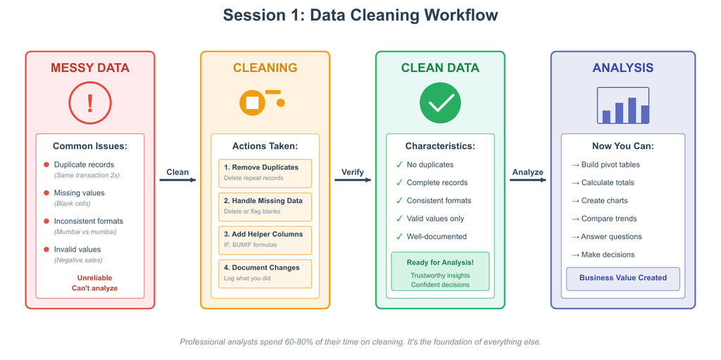

## Part 3: Remove Duplicates (15 minutes)

### Why Duplicates Are Dangerous

Imagine calculating total sales. If a ₹50,000 transaction appears twice, your total is inflated by ₹50,000. Multiply this across hundreds of records, and your CEO makes decisions based on false revenue numbers.

**Bottom line:** Duplicates destroy trust in your data.

### How to Remove Duplicates in Excel

**First make a copy of the data in another excel sheet.** You can do this by highlighting all the data by pressing **Ctrl-A** (select all), then pressing **Ctrl-C** (for Copy), clicking on the + icon at the bottom of the excel sheet ribbon to get a new blank excel sheet (Sheet1), and then pressing **Ctrl-V** (for Paste) in the top left hand corner cell (A1).

**Rename the new sheet Clean Data**. You can do this by right-clicking on Sheet1 and then typing Clean Data as the new name for that sheet.

**Example output:**

```
25 duplicate values found and removed; 1040 unique values remain.
```

## Part 4: Handle Missing Values (20 minutes)

### The Missing Data Decision Framework

Not all missing data should be handled the same way. You need to make decisions based on context.

**Three Questions to Ask:**

1. **How much is missing?**
   - If 50% of sales data is missing, the dataset might be unusable
   - If 5% is missing, you can work with it
2. **Is it random or systematic?**
   - Random: Missing values scattered throughout
   - Systematic: One branch never reports sales (bigger problem!)
3. **What’s the impact of deleting vs keeping?**
   - Will you lose critical information?
   - Can you work around it?

### Strategy: First Flag, then Delete Rows with Missing Sales

**When to use:** Sales is your primary analysis variable. A transaction without sales data is useless. It points to data problems. However, before deleting the data, it would be useful to flag the rows with missing sales data so we can first analyze the problems with missing data (maybe in some states/months?).

For this we will use the “IF” function in Excel.

### Introduction to IF Function

**Tip**

The IF function is one of Excel’s most powerful tools. It allows you to make decisions with data.

**Basic Syntax:**

```
=IF(condition, value_if_true, value_if_false)
```

**Real-world analogy:**

```
IF it's raining, bring an umbrella, otherwise bring sunglasses
```

**A. Steps to flag missing/blank sales data:**

1. **Create a new column**
   - Go to cell J1
   - Type **Sales_Flag** to create a flag for missing sales values and name the column
2. **Write the IF formula**
   - Click cell J2 (first data row)
   - Type this formula:

   ```
   =IF(ISBLANK(F2), 0, 1)
   ```

**B. Steps to delete missing/blank sales data:**

1. **Apply a filter as we did earlier by selecting Data—>Filter** (funnel icon)
   - Small dropdown arrows (▼) appear in headers
2. **Filter Sales_Flag column**
   - Click dropdown arrow in Sales_Flag (column J)
   - Uncheck “Select All”
   - Select 0 (we are looking at data with blank sales)
   - Click OK
3. **Examine the data with blank Sales**
   - Do you notice any patterns in the month column?
   - Which months/years had most blank Sales data?
   - Keep a note of your observations
4. **Select and delete filtered rows**
   - Click on row number of first visible row
   - Shift + Click on last visible row
   - Right-click → Delete Row
   - Select **Yes** in the dialogue box. that appears
5. **Clear the filter**
   - Click on the small arrow again in Sales_Flag
   - Click on clear filter. The rest of your data will be visible.
   - There will no longer be any sales data missing
6. **Document your decision**

   ```
   Removed 20 rows with missing Sales values
   because Sales is a primary metric for our analysis.
   ```

### Do the same steps for Missing Sales_Target

**When to use:** Sales_Target is informational, not critical. Some branches might not have targets set yet.

**Steps: Repeat A and B from above but this time for the Sales_Target column**

1. **Create a new column**
   - Click on cell K1
   - Type Target_Flag to give the column a header name
2. **Write the IF formula**
   - Click cell K2 (first data row)
   - Type this formula:

   ```
   =IF(ISBLANK(G2), 0, 1)
   ```

   - Press Enter
3. **Understand the formula**
   - `ISBLANK(G2)` checks if cell G2 is empty
   - If TRUE → displays 0
   - If FALSE → displays 1
4. **Copy formula down**
   - Click on cell K2
   - Double-click the small square in bottom-right corner (fill handle). The remaining rows will automatically get filled with the formula.
   - Or copy and paste down manually
   - Note what appears in the bottom of the screen (RHS).
   - Note down the count, average and sum.
5. **Document your decision**

6. **Remove rows with no Target_Sales by following the same steps as before.**

   ```
   Note down how many rows were removed.
   ```

### Your Documentation Should Include

For your cleaning log, write:

```
1. Flagged rows with missing Sales_Target
   - Created Target_Flag column using IF function
   - Reason: Target data is supplementary; transaction data still valuable
   - Pattern observed: Missing Targets & Sales in West Bengal, UP mostly
```

## Part 5: Further Examples with IF (25 minutes)

### Example 1: Target Achievement Flag

Let’s create a column that shows whether each transaction met its sales target.

**Step 1: Insert new column** - Insert a column next to Target_Flag - Name it: **Performance** by typing it in cell **L1**.

**Step 2: Write the formula** - Click on first data cell in Performance column - Type:

```
=IF(F2>=G2,1,0)
```

**Step 3: Understand the logic** - `F2>=G2` asks: “Is Sales greater than or equal to Target?” - If YES → 1 (Target Met) - If NO → 0 (Target Missed)

**Step 4: Copy down** - Double-click fill handle or copy down manually.

**Step 5:** Note what is written in the bottom right corner of the screen.

✓ You now have a clear performance flag for every transaction!

### Example 2: Performance Rating (Nested IF)

Let’s get more sophisticated with a three-tier rating.

**Create a new column: Performance_Rating Flag in Column M.** Go to cell **M1** and type Performance_Rating to give this column a name. Then move to cell M2 and type the formula below.

**Formula:**

```
=IF(F2>=G2*1.1, "Excellent", IF(F2>=G2, "Good", "Needs Improvement"))
```

**Logic breakdown:** 1. First check: Did sales exceed target by 10% or more? → “Excellent” 2. If not, second check: Did sales at least meet target? → “Good” 3. If not → “Needs Improvement”

**This is called a “nested IF”** - one IF inside another.

### Example 3: High-Value Transaction Flag

Create a flag for Sales transactions above ₹75,000.

**Column name:** High_Value

**Formula:**

```
=IF(F2>75000, "High Value", "Standard")
```

#### Simple but powerful for filtering and analysis later!

## Part 6: Think About Questions (Ongoing)

Throughout the session, keep asking yourself:

### Questions This Dataset CAN Answer

Think about what’s actually in the data. Examples:

1. **Which state has the highest total sales?**
   - We have State and Sales columns → Yes!
2. **Are sales targets being met across different channels?**
   - We have Sales, Sales_Target, and Sales_Channel → Yes!
3. **Which product line generates the most sales?**
   - We have Product_Line and Sales → Yes!
4. **How do B2B sales compare to B2C sales?**
   - We have Customer_Segment and Sales → Yes!
5. **What’s the average transaction value by state?**
   - We have State and Sales → Yes!

### Questions This Dataset CANNOT Answer

Think about what’s missing. Examples:

1. **Why did sales drop in March?**
   - We have numbers but no context (no reason field) → No!
2. **What do customers think about our products?**
   - No customer feedback or satisfaction data → No!
3. **How do our prices compare to competitors?**
   - No competitor pricing data → No!
4. **Which marketing campaigns drove the most sales?**
   - No campaign or marketing data → No!
5. **What is the profit margin on each transaction?**
   - We have sales but no profit data → No! (Unless we add it via lookup in another table where such information exists. We will do this in Session 2)

### Why This Matters

Understanding what you CAN’T answer is as important as knowing what you CAN answer. It: - Prevents you from making claims beyond your data - Helps you identify what additional data you need - Makes you a more credible analyst

**For your deliverable, write:** - 3 specific questions this dataset CAN answer - 2 specific questions it CANNOT answer - Brief explanation of why for each

## Your Deliverables Checklist

By the end of this session, you should have:

### ✓ 3 Questions This Dataset CAN Answer

Write them clearly with brief explanations:

```
Example:
1. Which state has the highest sales?
   → Can answer because we have State and Sales columns
```

### ✓ 2 Questions This Dataset CANNOT Answer

```
Example:
1. Why did specific transactions fail to meet targets?
   → Cannot answer because we have no contextual/reason data
```

### ✓ Data Quality Observation (2-3 lines)

[output not shown]

### ✓ Cleaned Dataset

- No duplicate Transaction IDs
- Flags for missing Sales and Target data
- Removed data with missing sales or targets
- Performance flags created

### ✓ Cleaning Log (example)

[output not shown]

## Common Mistakes to Avoid

❌ **Deleting data without documenting why** - Always keep a cleaning log

❌ **Not keeping a backup of original data** - Save a copy before cleaning

❌ **Not checking your formulas** - Always verify on a few rows manually

❌ **Assuming missing data is random** - Always investigate patterns in missing data

## Key Takeaways

✓ **Always befriend your data first** - Don’t jump into analysis before understanding what you have

✓ **Question everything** - Just because data exists doesn’t mean it’s correct or complete

✓ **Data has limits** - Knowing what you CAN’T answer is as important as knowing what you CAN

✓ **Context matters** - Numbers without context are just numbers

✓ **Document your decisions** - Future you (and your boss) will thank you

✓ **Clean data is the foundation** - No analysis is reliable without it

✓ **Always backup data before cleaning** - You will lose the original data otherwise

## What’s Next?

**Session 2: Excel Formulas + Table Lookups**

Now that your data is clean, you’ll learn to: - Master SUMIF, COUNTIF, and AVERAGEIF for conditional calculations - Use VLOOKUP/XLOOKUP to combine data from multiple sources - Enrich your dataset with additional information - Build comprehensive summary tables - Calculate derived metrics like profit

**The journey continues:** Clean data + Powerful formulas = Business intelligence

## Questions to Reflect On

Before next session, think about:

1. How would bad data lead to bad business decisions in your organization?
2. What’s the cost (time, money, reputation) of working with messy data?
3. Why do you think data quality issues exist in the first place?
4. What role does documentation play in professional data work?

*Module 3: Excel & Data Analytics | Session 1 of 4*